# Análisis Exploratorio Univariado - Películas

Delia Del Águila

En este documento analizaremos 5mil películas obtenidas de http://www.imdb.com/, beses de datos de películas en Internet pos sus siglas en inglés.

### Limpieza

Nuestro dataset inicia con 5,043 registros y 28 variables. A lo largo del proceso de limpieza nos enocntramos con:  
1. Registros duplicados  
2. Remakes, es decir una nueva versión de la película  
3. Registros de películas duplicadas pero con valores distintos en algún campo  
Despues del proceso de limpieza nuestro dataset termina con 4,911 películas.

### Conociendo nuestro dataset

Veamos las variables pricipales **Movie Title:** Título de la película. 4,911 títulos diferentes.

**Color:** Nos indica si la película es a Color o a Blanco y Negro. El 95% de las películas dentro del dataset son a color.  
**Title Year:** El año en que la película fue lanzada. Desde 1916 hasta el 2016.  
**FB Likes:** En nuestro dataset tenemos información de facebook likes sobre la película, el director, el 1, 2 y 3 actor, y sobre el elenco completo. Notemos que las películas a blanco y negro no solo están presentes en los años 90, también hay registros del 2000 en adelante.  
Además pareciera que las películas antiguas estarían en desventaja sobre los likes de Facebook, pero vemos que esto no necsariamente es así cuando hablamos de películas exitosas como Titanic.

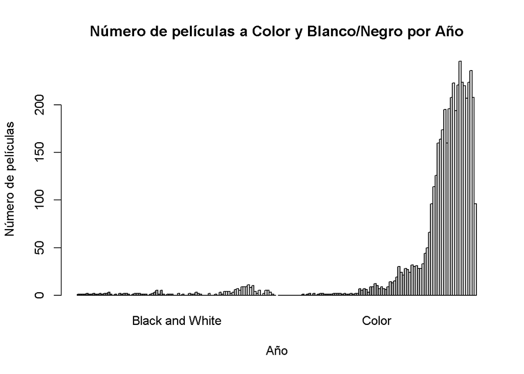

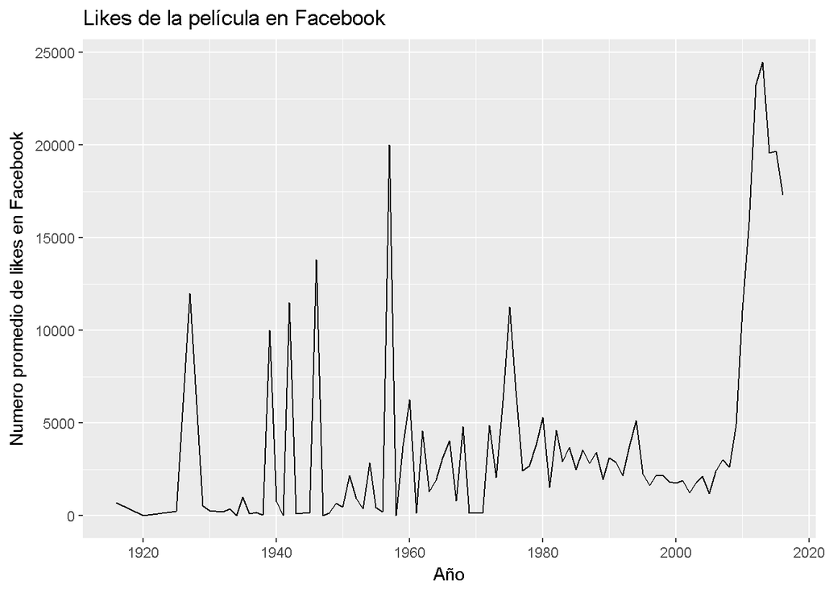

**Number of Critics for Review:** Número de críticos que revisaron la película. En nuestro dataset encontramos desde ningun crítico hasta 813 criticos para la revisión de una sola película.  
**Language:** Idioma en que la película fue filmada. Los más comunes son Inglés, Español y Frances.  
Notemos que son más los criticos para el idioma inglés.

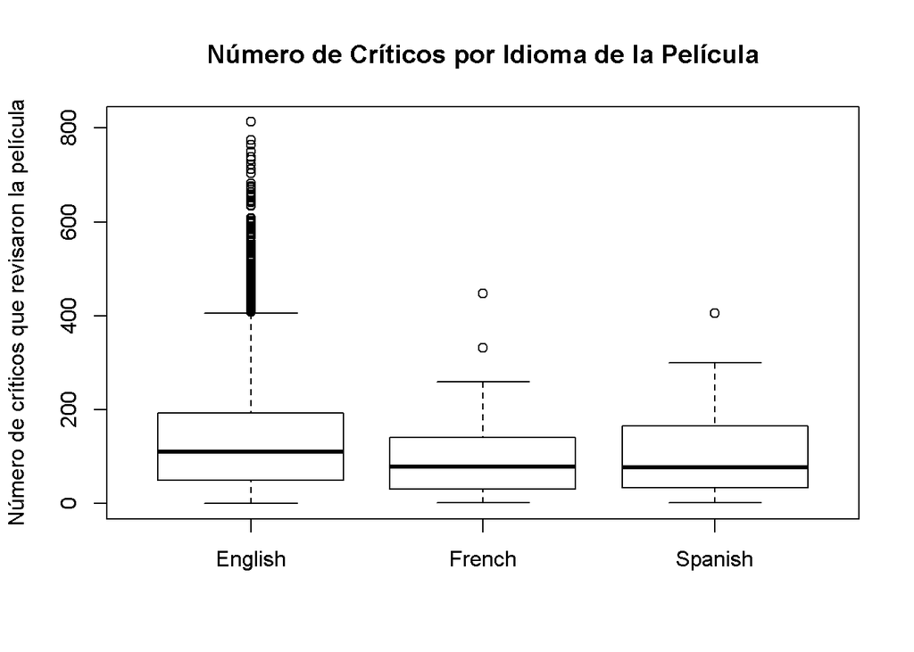

**Duration:** Duración del video en minutos. Desde 7 minutos con Shaun the Sheep hasta 511 minutos con Trapped. Con esto podemos notar que nuestra base de datos no solo incluye películas también incluye series, ya sea solo un capítulo o la serie completa. Shaun the Sheep se refiere a un episodío de la serie pero en el caso de Trapped se refiere a la duración de toda la serie.

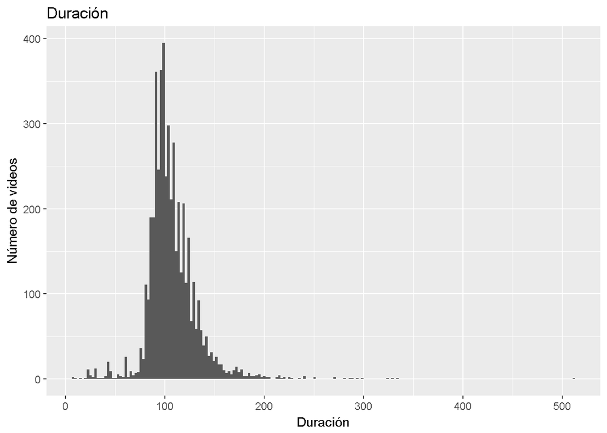

**Genres:** Genero del video. 26 generos con 913 combinaciones de generos diferentes. El genero más popular es Drama.

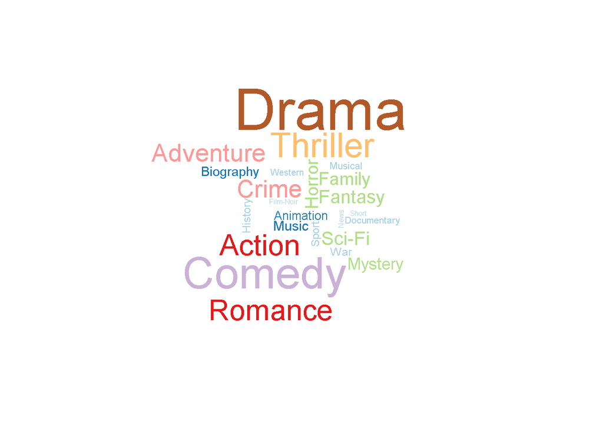

**Country:** País.  
**Budget:** Presupuesto.  
Los países mas populares son USA, UK, Francia y Canada, y estos mismos son los que invierten más en sus películas.

### Correlaciones

**Gross:** Ganancia bruta.  
Tenemos 859 registros con NA el cual refleja una ausencia de dato y no necesariamente que esa película no tuvo ganancias, como es el caso de Star Wars: Episode VII - The Force Awakens la cual ha tenido mas de 2 mil millones de dolares de ingresos.  
Los registros de ganancia van desde los 162 en la película Skin Trade hasta los 760,505,847 con la película Avatar.

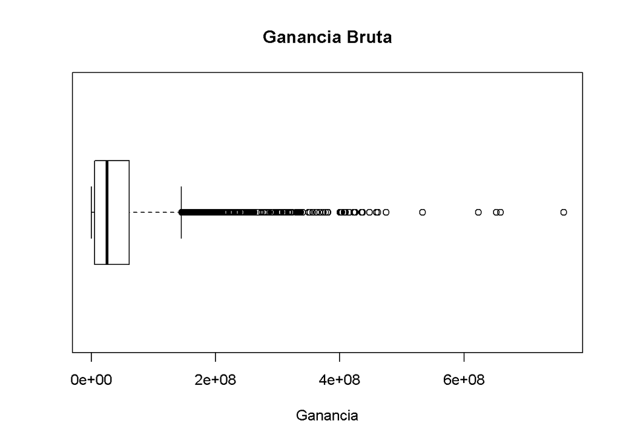

Notemos que la Ganacia está correlacionada con la Inversion en 0.41 y con la cantidad de FB likes que tiene la película con 0.36

```
##                   Director_FB_likes     Gross Movie_FB_Likes     Budget
## Director_FB_likes        1.00000000 0.1409881      0.1664340 0.05998051
## Gross                    0.14098811 1.0000000      0.3644570 0.41034900
## Movie_FB_Likes           0.16643403 0.3644570      1.0000000 0.19438818
## Budget                   0.05998051 0.4103490      0.1943882 1.00000000
## IMDB_Score               0.19191535 0.2137914      0.2829380 0.03483764
##                   IMDB_Score
## Director_FB_likes 0.19191535
## Gross             0.21379142
## Movie_FB_Likes    0.28293795
## Budget            0.03483764
## IMDB_Score        1.00000000
```

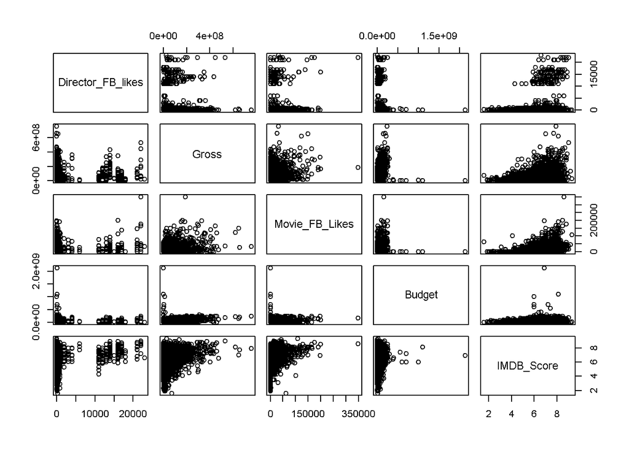